# Hw2

**2. Explore the distribution of price. Do you discover anything unusual or surprising? (Hint: Carefully think about the binwidth and make sure you try a wide range of values.)**

```r
#Define price variable
price <- diamonds$price

#Check min and max of price
min(price)
```

```
## [1] 326
```

```r
max(price)
```

```
## [1] 18823
```

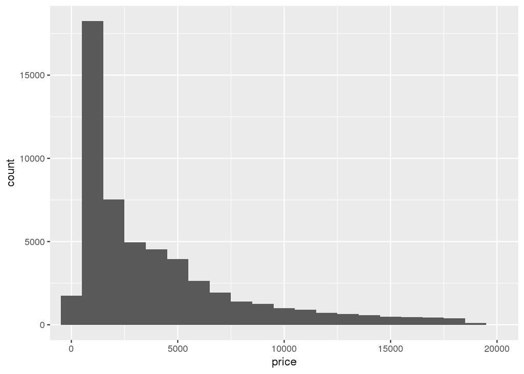

```r
#Price has a huge range ($326 to $18,823)


#Make histogram and explore bin widths

#bin width of 1000
ggplot(diamonds) +
 geom_histogram(mapping = aes(x = price), binwidth = 1000) +
 coord_cartesian(xlim = c(0, 20000))
```

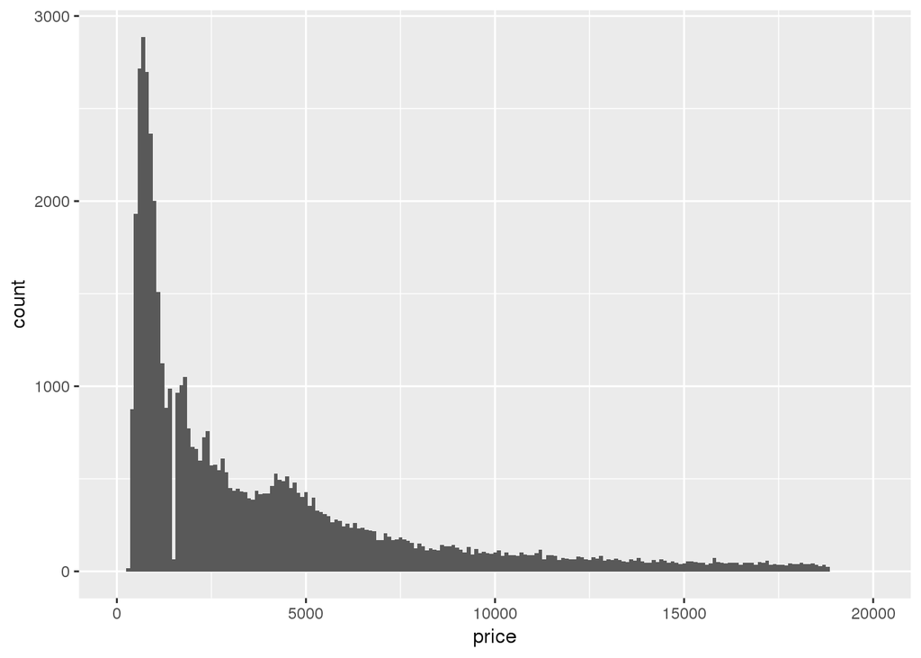

```r
#bin width of 100
ggplot(diamonds) +
 geom_histogram(mapping = aes(x = price), binwidth = 100) +
 coord_cartesian(xlim = c(0, 20000))
```

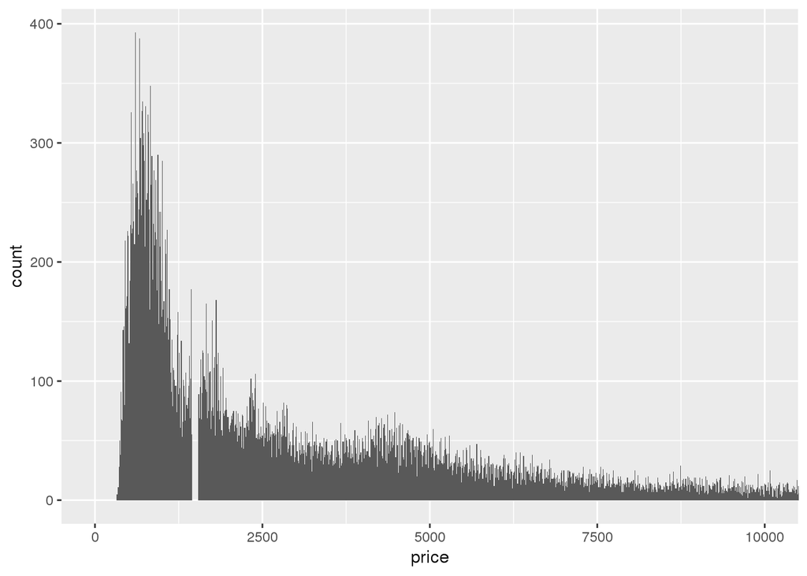

```r
#Note, there is a price gap around $1500-$2000

#Take a closer look at the data
ggplot(diamonds) +
 geom_histogram(mapping = aes(x = price), binwidth = 10) +
 coord_cartesian(xlim = c(0, 10000))
```

**3. How many diamonds are 0.99 carat? How many are 1 carat? What do you think is the cause of the difference?**

```r
#Define carat variable
carat <- diamonds$carat

filter_carat <- diamonds %>%
  filter(carat >= 0.99, carat <= 1)

#Define filtered carat variable
filtered_carat <- filter_carat$carat

#Check if code worked. Min and max should be between 0.99 and 1
min(filtered_carat)
```

```
## [1] 0.99
```

```r
max(filtered_carat)
```

```
## [1] 1
```

```r
#Count 0.99 carat diamonds and 1 carat diamonds
count_0.99 <- which(filtered_carat == 0.99)
length(count_0.99)
```

```
## [1] 23
```

```r
count_1 <- which(filtered_carat == 1)
length(count_1)
```

```
## [1] 1558
```

There are 23 0.99 carat diamonds and 1558 1 carat diamonds. One possible explanation is diamond sellers are being intentionally dishonest. In particular, sellers likely falsely advertise 0.99 carat diamonds as 1 carat diamonds because there is such a small difference between the two, and sellers would “round up” the carat number. I suspect that 1 carat diamonds are much more valuable than 0.99 carat diamonds, so sellers would tend to advertise their 0.99 carat diamonds as 1 carat diamonds instead of as 0.99 carat diamonds. Therefore, there would be significantly less 0.99 carat diamonds than 1 carat diamonds.

**4. Compare and contrast coord_cartesian() vs xlim() or ylim() when zooming in on a histogram. What happens if you leave binwidth unset? What happens if you try and zoom so only half a bar shows?**

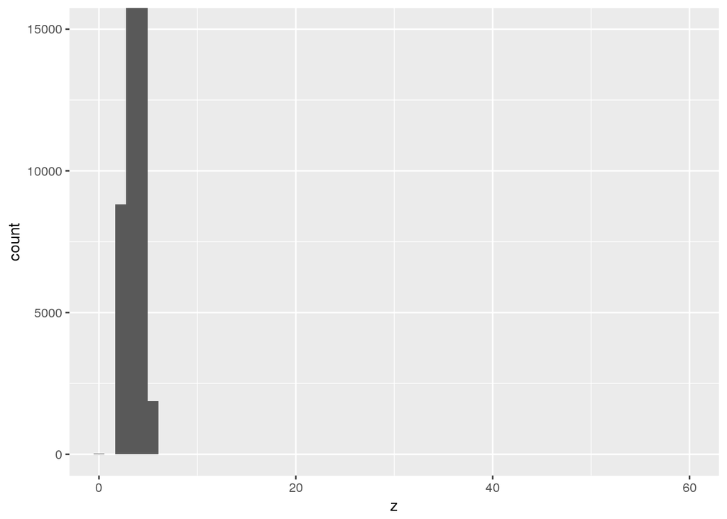

```r
#Compare and contrast histograms.

#Do not set bin width. When doing histograms for x, y and z,
#I got errors about "set better bin width" when I did not set bin widths

#Leave bin width unset for z histogram
ggplot(diamonds) +
  geom_histogram(mapping = aes(x = z)) +
  coord_cartesian(xlim = c(0, 60), ylim = c(0, 15000))
```

[output not shown]

[output not shown]

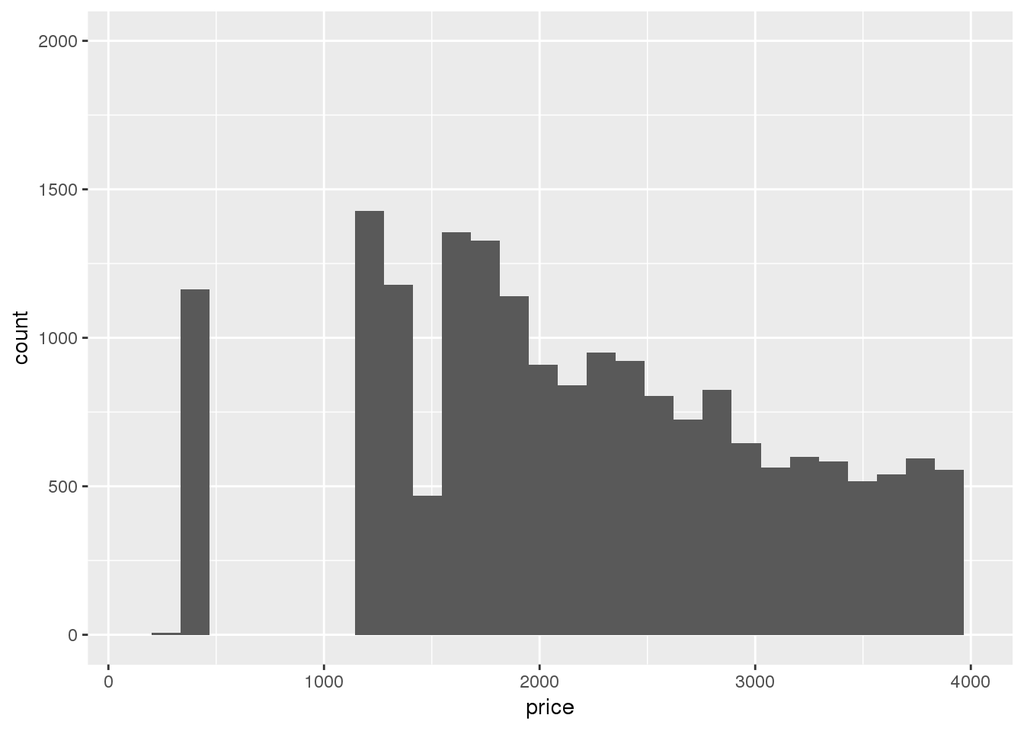

```r
#Do not use coord_cartesian
#Make xlim smaller than it should be (excludes values)
#Look at price data

ggplot(diamonds) +
 geom_histogram(mapping = aes(x = price)) +
  xlim(100, 4000) +
  ylim(0, 2000)
```

Coord_cartesian looks closer at the specified x and y limits on the histogram. If bin widths are not set, ggplot automatically sets bins = 30 and if this bin width is inappropriate, R will still draw the plot, but will give a warning message asking the user to input better bin widths. Coord_cartesian will not exlude data, but the values will be cut off if the user zooms in.

# Exercise 7.4.1

**1. What happens to missing values in a histogram? What happens to missing values in a bar chart? Why is there a difference?**

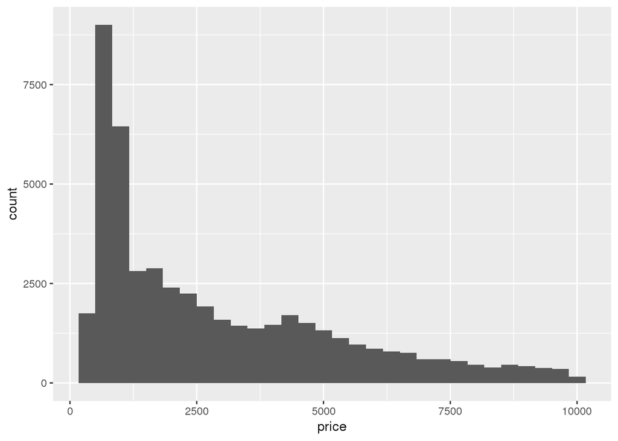

```r
diamonds2 <- diamonds %>%
  mutate(price = ifelse(price > 10000, NA, price))

diamonds2 %>%
  ggplot(aes(price)) +
  geom_histogram()
```

In a histogram for a continuous variable, missing values are not included in the binwidth calculation so they do not show up on the histogram.

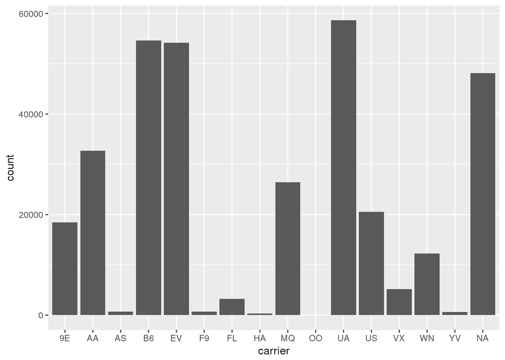

```r
flights %>%
  mutate(carrier = ifelse(carrier == "DL", NA, carrier)) %>%
  ggplot(aes(carrier)) +
  geom_bar()
```

For discrete values in a barplot, missing values are treated as a new category. In this case, NA represents missing values so there is a category for NA

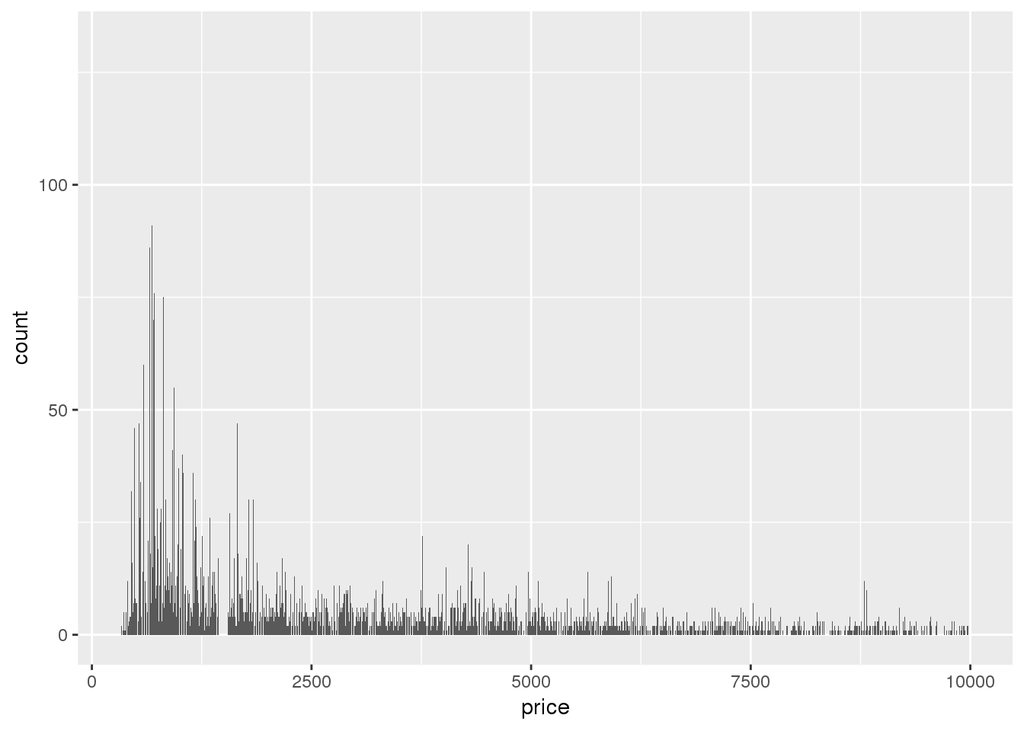

```r
diamonds2 %>%
  ggplot(aes(price)) +
  geom_bar()
```

For continuous values, in a barplot, missing values are omitted in the plot. Note in this plot, prices greater than $10,000 ommitted (See plot below for comparison)

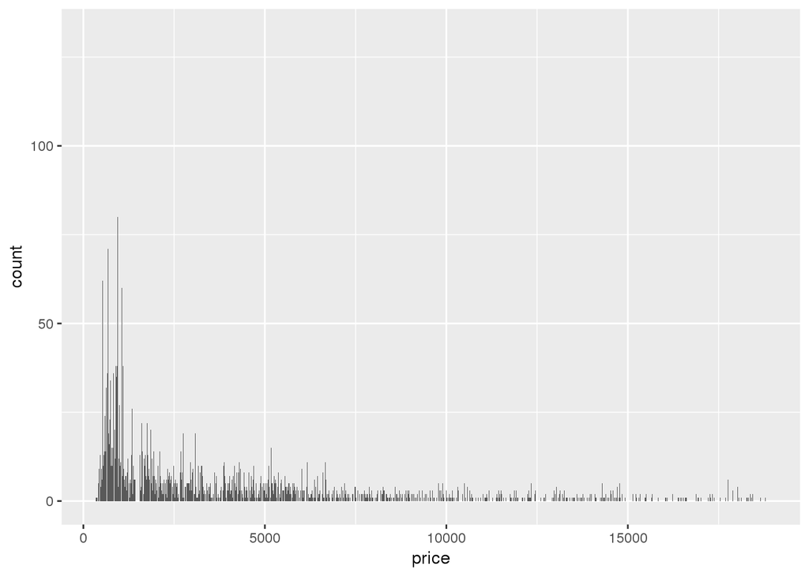

```r
diamonds %>%
  ggplot(aes(price)) +
  geom_bar()
```

There is a difference in ommitted values in histograms vs. bar plots because histograms and bar charts are constructed differently. Histograms are constructed based off frequency of data points based on bin width. Histograms provide insight on the shape of the distribution of the data as well as measures of central tendency. Including a separate cateogry counting “NAs” would not be helpful in describing the shape of the distribution of the data. In other words, NA values do not give any helpful information in a histogram. In the histogram of diamond price, diamonds worth more than $10,000 were filtered out. The histogram should be constructed such that it represents the distribution of diamonds worth less than $10,000.

On the other hand, it is useful to include NA for bar charts because bar charts are good for visualizing categorical data. Therefore, having a category for NA helps one understand what the data looks like. The histogram with flights in 2013 has the carrier Delta airlines as NA for visualization purposes. The bar chart adds a category for NA, and this helps visualize all the information in the data for flights in 2013 for NYC. In short, it is helpful to see how many NA values there are for categorical data.

**2. What does na.rm = TRUE do in mean() and sum()?**

```r
mean(c(1, 2, 3, NA), na.rm = TRUE)
```

```
## [1] 2
```

```r
#Mean of this vector is (1 + 2 + 3) / 3 = 2


sum(c(1, 2, 3, NA), na.rm = TRUE)
```

```
## [1] 6
```

```r
#Sum of this vector is (1 + 2 + 3) = 6
```

The na.rm command removes NA values from the specified vector. So, these missing data points are are not included in the mean() nor the sum() calculation.

# 7.5.1.1 Exercises

**1. Use what you’ve learned to improve the visualisation of the departure times of cancelled vs. non-cancelled flights.**

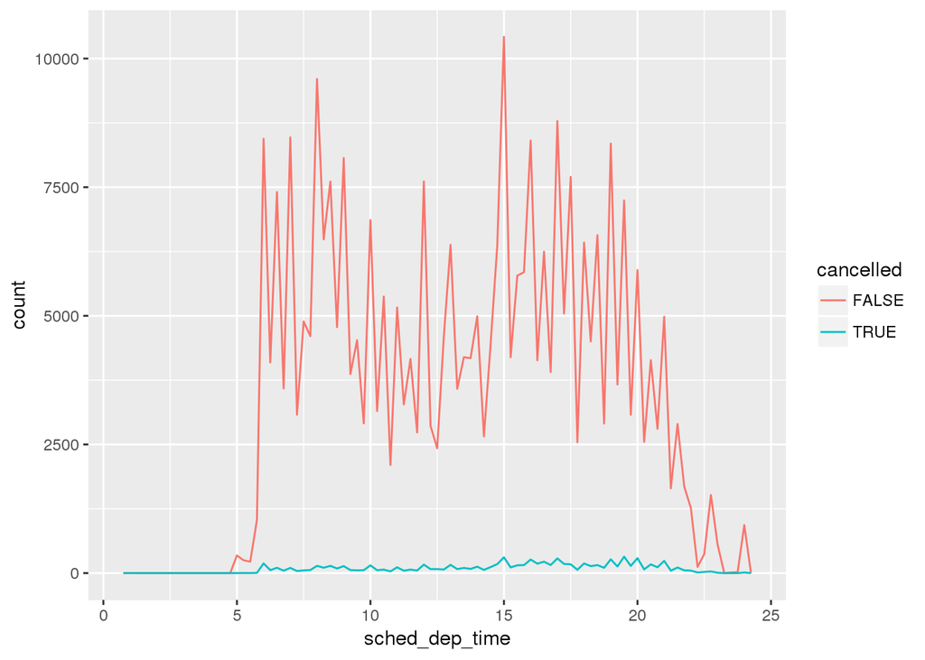

```r
#Original given plot
flights %>%
  mutate(
    cancelled = is.na(dep_time),
    sched_hour = sched_dep_time %/% 100,
    sched_min = sched_dep_time %% 100,
    sched_dep_time = sched_hour + sched_min / 60
  ) %>%
  ggplot(mapping = aes(sched_dep_time)) +
  geom_freqpoly(mapping = aes(colour = cancelled), binwidth = 1/4)
```

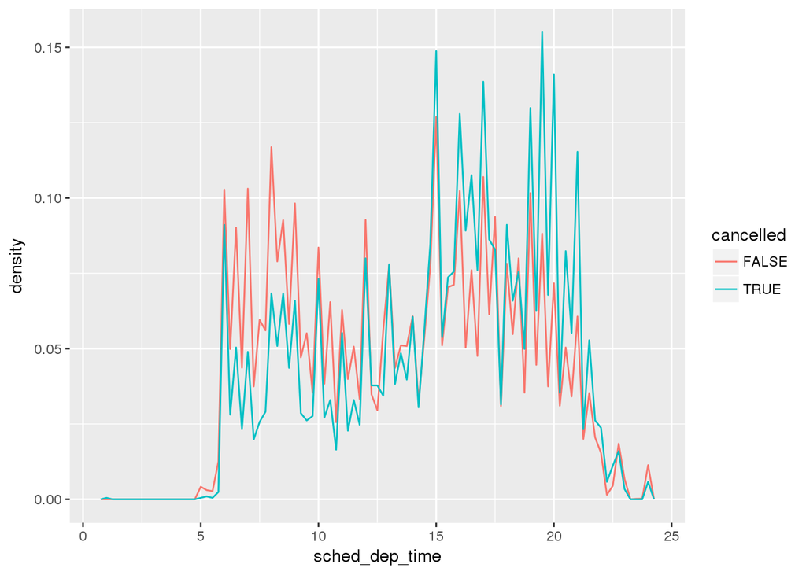

```r
#Remove mapping in both ggplot and geom_freqpoly command
#Move color = cancelled into ggplot command

flights %>%
  mutate(
    cancelled = is.na(dep_time),
    sched_hour = sched_dep_time %/% 100,
    sched_min = sched_dep_time %% 100,
    sched_dep_time = sched_hour + sched_min / 60
  ) %>%
  ggplot(aes(x = sched_dep_time, y = ..density.., color = cancelled)) +
  geom_freqpoly(binwidth = 1/4)
```

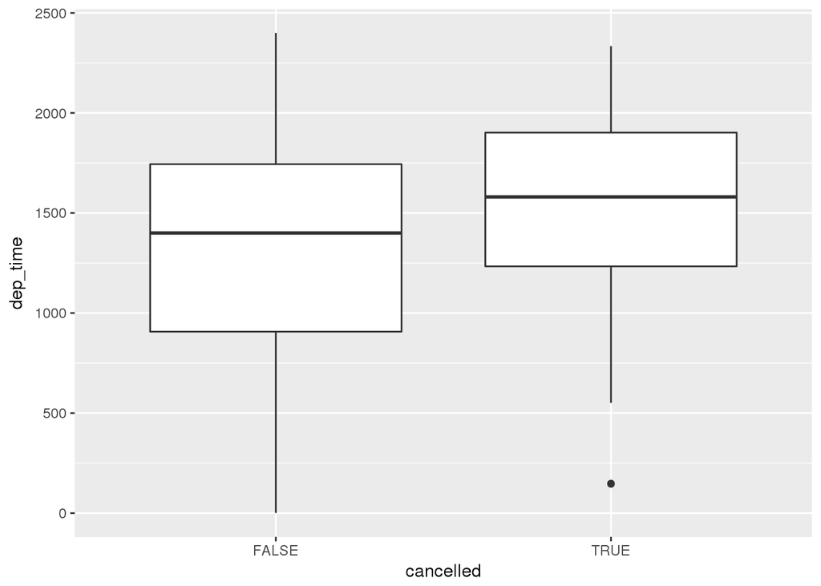

```r
#Or, visualize cancelled flights with a boxplot
flights %>%
  mutate(cancelled = is.na(dep_time) | is.na(arr_time)) %>%
  ggplot() +
  geom_boxplot(aes(x = cancelled, y = dep_time))
```

**2. What variable in the diamonds dataset is most important for predicting the price of a diamond? How is that variable correlated with cut? Why does the combination of those two relationships lead to lower quality diamonds being more expensive?**

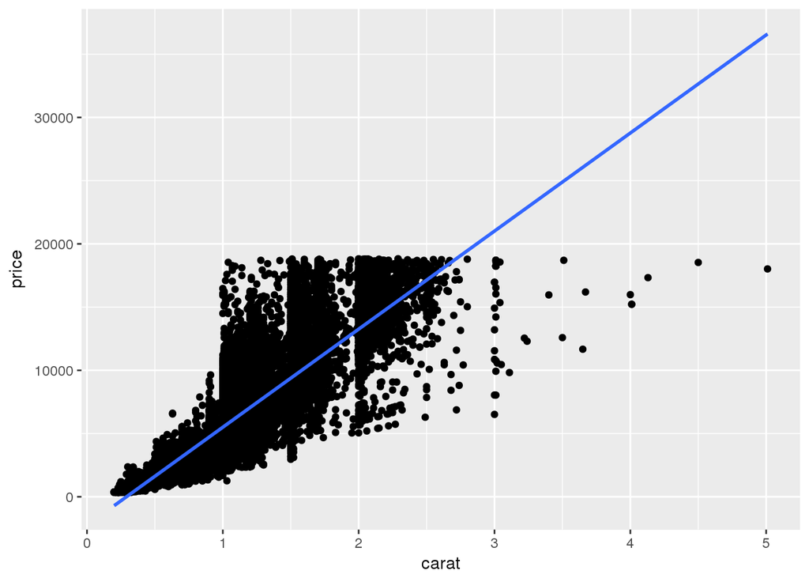

```r
ggplot(diamonds, aes(carat,price)) +
  geom_point() +
  geom_smooth(method = "lm")
```

```r
fit <- lm(diamonds$price ~ diamonds$carat, data = diamonds)
summary(fit)
```

```
##
## Call:
## lm(formula = diamonds$price ~ diamonds$carat, data = diamonds)
##
## Residuals:
##      Min       1Q   Median       3Q      Max
## -18585.3   -804.8    -18.9    537.4  12731.7
##
## Coefficients:
##                Estimate Std. Error t value Pr(>|t|)
## (Intercept)    -2256.36      13.06  -172.8   <2e-16 ***
## diamonds$carat  7756.43      14.07   551.4   <2e-16 ***
## ---
## Signif. codes:  0 '***' 0.001 '**' 0.01 '*' 0.05 '.' 0.1 ' ' 1
##
## Residual standard error: 1549 on 53938 degrees of freedom
## Multiple R-squared:  0.8493, Adjusted R-squared:  0.8493
## F-statistic: 3.041e+05 on 1 and 53938 DF,  p-value: < 2.2e-16
```

```r
#Adj R^2 value is high (0.85)
```

Carat is important in predicting diamond price. Fitting a linear regression of price vs. carat shows the adjusted R^2 value is high (0.85), but this may not be the best model to fit the data.

*Fit a non-linear regression (Loess) curve instead*

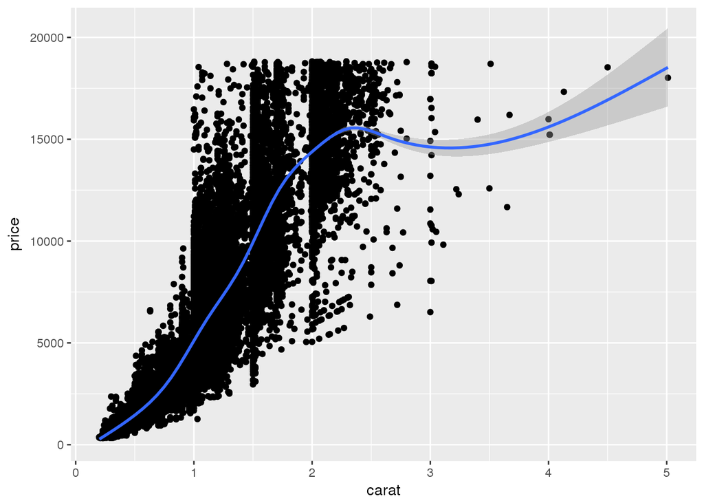

```r
ggplot(diamonds, aes(carat, price)) +
  geom_point() +
  geom_smooth()
```

*To examine the relationship between cut and carat, a boxplot can also be used*

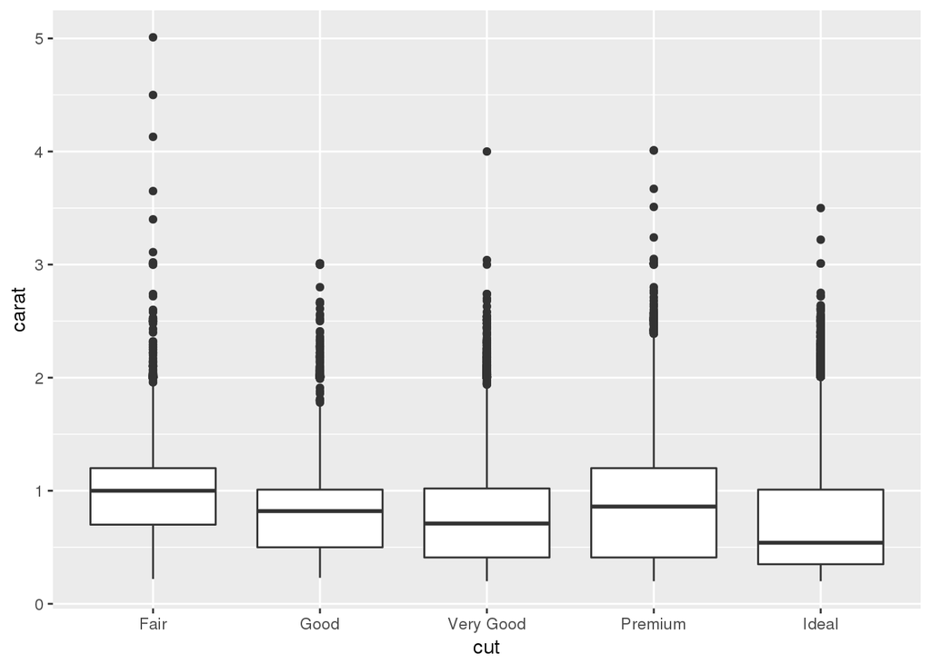

```r
diamonds %>%
  ggplot(aes(cut, carat)) +
  geom_boxplot()
```

The combination of carat and cut leads to lower quality diamonds being more expensive because the combination of these two variables is important in predicting price. Low quality diamonds can have large carats, and since carat is an important predictor of price, the larger the diamond, the more it is worth (even though the quality of the cut is low). This allows lower quality diamonds to be more expensive. Similarly, small but high quality cut diamonds can be very expensive.